# Evaluación

```python
import numpy as np # linear algebra
import pandas as pd # data processing, CSV file I/O (e.g. pd.read_csv)
import os
#print(os.listdir("datos"))
import matplotlib.pyplot as plt
import seaborn as sns
from sklearn.model_selection import cross_val_score
from sklearn.linear_model import LinearRegression
from sklearn.linear_model import Lasso
from sklearn.linear_model import Ridge
from sklearn.model_selection import GridSearchCV
from sklearn.metrics import mean_squared_error
from sklearn.preprocessing import MinMaxScaler
from sklearn.metrics import make_scorer
from sklearn.pipeline import Pipeline
from sklearn.linear_model import RidgeCV
```

## Reentrenamiento final de modelo con datos de entrenamiento y prueba con hiperparámetros optimizados.

El modelo que mejor se desempeñó en la validación fue el XGBOOST. A continuación se ajusta el modelo final sobre todos los datos de entrenamiento y prueba.

```python
training = pd.read_csv("Data_Modelos/Entrenamiento_Modelos.csv")
```

```python
import xgboost as xgb
```

```python
xgbtrain = xgb.DMatrix(training.iloc[:, training.columns != 'item_cnt_day'].values,
                       training.iloc[:, training.columns == 'item_cnt_day'].values)

param = {'max_depth':10,
         'subsample':1,
         'min_child_weight':0.5,
         'eta':0.3,
         'num_round':1000,
         'seed':1,
         'silent':0,
         'eval_metric':'rmse'} # random parameters
bst = xgb.train(param, xgbtrain)
```

[output not shown]

En la siguiente gráfica se muestra la importancia de las características.

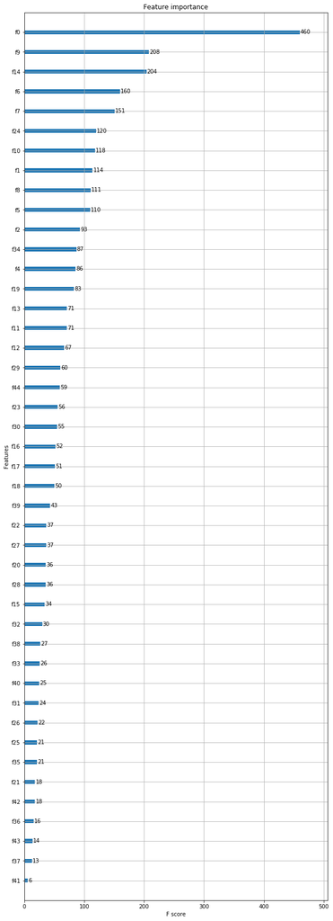

```python
x=xgb.plot_importance(bst)
x.figure.set_size_inches(10, 30)
```

```python
cols = list(training.columns)
del cols[cols.index('item_cnt_day')] # Se elimina la variable target day
[cols[x] for x in [0, 8, 13, 5, 1, 6, 9, 2, 23]]
```

```
['Unnamed: 0',
 'shop_id_avg_item_price_lag_1',
 'item_category_id_avg_item_cnt_day_lag_1',
 'item_id_avg_item_price_lag_1',
 'shop_id',
 'item_id_sum_item_cnt_day_lag_1',
 'shop_id_sum_item_cnt_day_lag_1',
 'item_id',
 'item_category_id_avg_item_cnt_day_lag_2']
```

Una vez ajustado el modelo se procede a ajustar el modelo sobre el conjunto de prueba.

```python
test = pd.read_csv("Data_Modelos/Prueba_Modelos.csv")
```

```python
xgbpredict = xgb.DMatrix(test.values)
```

```python
pred = bst.predict(xgbpredict)
```

Se puede observar que para el mes de noviembre de 2015 se predijó la cantidad de unidades vendidas para 214,200 productos por tienda. Algunos valores quedan fuera del rango de 0 y 20, por lo que se deberán ajustar los valores extremos.

```python
pd.Series(pred).describe()
```

```
count    214200.000000
mean          0.312726
std           2.588174
min          -0.577917
25%           0.058912
50%           0.120540
75%           0.240221
max         386.479553
dtype: float64
```

Se ajustan los valores predichos para que queden en un rango de 0 y 20 como se especificó en las instrucciones de la competencia.

```python
pred = pred.clip(0, 20)
```

Se puede ver que ahora todos los valores quedaron dentro del rango requerido.

```python
pd.Series(pred).describe()
```

```
count    214200.000000
mean          0.284587
std           0.794151
min           0.000000
25%           0.058912
50%           0.120540
75%           0.240221
max          20.000000
dtype: float64
```

Las ventas totales de la empresa 1C durante el mes de noviembre de 2015 se proyectaron en 60,966 unidades.

```python
pred.sum()
```

```
60966.914
```

```python
sub_df = pd.DataFrame({'ID':test.index,'item_cnt_month': pred })
```

```python
sub_df.head()
```

|  | ID | item_cnt_month |
| --- | --- | --- |
| 0 | 0 | 0.418297 |
| 1 | 1 | 0.192049 |
| 2 | 2 | 1.003844 |
| 3 | 3 | 0.212420 |
| 4 | 4 | 2.626056 |

## Generación y carga de datos de prueba en Kaggle (reporte de posición final en tablero)

Se genera el archivo de predicciones para subir a Kaggle.

```python
sub_df.to_csv('Modelo_Final/submission.csv',index=False)
```

## Guardamos el modelo final en pickle para utilizarlo para hacer predicciones en el WEB SERVICE

Ahora guardamos el modelo en Pickle para posteriormente utilizarlo en el WEB SERVICE en Flask.

```python
from sklearn.externals import joblib
joblib.dump(bst, 'Modelo_Final/modelo_xgb_prueba.pkl')
```

```
['Modelo_Final/modelo_xgb_prueba.pkl']
```

# Predicción Xgboost con el mejor modelo

```python
train = pd.read_csv("Data_Modelos/Entrenamiento_Modelos2.csv", header = 0)
```

```python
train.head()
```

|  | shop_id | item_id | date_block_num | item_cnt_day | item_category_id | item_id_avg_item_price_lag_1 | item_id_sum_item_cnt_day_lag_1 | item_id_avg_item_cnt_day_lag_1 | shop_id_avg_item_price_lag_1 | shop_id_sum_item_cnt_day_lag_1 | ... | item_id_avg_item_price_lag_6 | item_id_sum_item_cnt_day_lag_6 | item_id_avg_item_cnt_day_lag_6 | shop_id_avg_item_price_lag_6 | shop_id_sum_item_cnt_day_lag_6 | shop_id_avg_item_cnt_day_lag_6 | item_category_id_avg_item_price_lag_6 | item_category_id_sum_item_cnt_day_lag_6 | item_category_id_avg_item_cnt_day_lag_6 | item_cnt_day_lag_6 |
| --- | --- | --- | --- | --- | --- | --- | --- | --- | --- | --- | --- | --- | --- | --- | --- | --- | --- | --- | --- | --- | --- |
| 0 | 27 | 15242 | 13 | 2.0 | 63 | 670.333333 | 9.0 | 1.000000 | 933.352539 | 5451.0 | ... | 699.0 | 25.0 | 1.000000 | 667.358769 | 4925.0 | 1.216049 | 471.065521 | 1688.0 | 1.113456 | 1.0 |
| 1 | 27 | 15200 | 13 | 1.0 | 69 | 499.000000 | 1.0 | 1.000000 | 933.352539 | 5451.0 | ... | 499.0 | 2.0 | 1.000000 | 667.358769 | 4925.0 | 1.216049 | 529.262542 | 665.0 | 1.112040 | 0.0 |
| 2 | 27 | 15279 | 13 | 2.0 | 63 | 798.112222 | 48.0 | 1.066667 | 933.352539 | 5451.0 | ... | 299.0 | 0.0 | 0.000000 | 936.124454 | 0.0 | 0.000000 | 398.799552 | 0.0 | 0.000000 | 0.0 |
| 3 | 27 | 15202 | 13 | 1.0 | 69 | 499.000000 | 2.0 | 1.000000 | 933.352539 | 5451.0 | ... | 499.0 | 2.0 | 1.000000 | 667.358769 | 4925.0 | 1.216049 | 529.262542 | 665.0 | 1.112040 | 0.0 |
| 4 | 27 | 14888 | 13 | 1.0 | 55 | 549.000000 | 21.0 | 1.000000 | 933.352539 | 5451.0 | ... | 549.0 | 10.0 | 1.666667 | 667.358769 | 4925.0 | 1.216049 | 270.202402 | 14131.0 | 1.019921 | 1.0 |

5 rows × 45 columns

```python
list(train.columns)
```

```
['shop_id',
 'item_id',
 'date_block_num',
 'item_cnt_day',
 'item_category_id',
 'item_id_avg_item_price_lag_1',
 'item_id_sum_item_cnt_day_lag_1',
 'item_id_avg_item_cnt_day_lag_1',
 'shop_id_avg_item_price_lag_1',
 'shop_id_sum_item_cnt_day_lag_1',
 'shop_id_avg_item_cnt_day_lag_1',
 'item_category_id_avg_item_price_lag_1',
 'item_category_id_sum_item_cnt_day_lag_1',
 'item_category_id_avg_item_cnt_day_lag_1',
 'item_cnt_day_lag_1',
 'item_id_avg_item_price_lag_2',
 'item_id_sum_item_cnt_day_lag_2',
 'item_id_avg_item_cnt_day_lag_2',
 'shop_id_avg_item_price_lag_2',
 'shop_id_sum_item_cnt_day_lag_2',
 'shop_id_avg_item_cnt_day_lag_2',
 'item_category_id_avg_item_price_lag_2',
 'item_category_id_sum_item_cnt_day_lag_2',
 'item_category_id_avg_item_cnt_day_lag_2',
 'item_cnt_day_lag_2',
 'item_id_avg_item_price_lag_3',
 'item_id_sum_item_cnt_day_lag_3',
 'item_id_avg_item_cnt_day_lag_3',
 'shop_id_avg_item_price_lag_3',
 'shop_id_sum_item_cnt_day_lag_3',
 'shop_id_avg_item_cnt_day_lag_3',
 'item_category_id_avg_item_price_lag_3',
 'item_category_id_sum_item_cnt_day_lag_3',
 'item_category_id_avg_item_cnt_day_lag_3',
 'item_cnt_day_lag_3',
 'item_id_avg_item_price_lag_6',
 'item_id_sum_item_cnt_day_lag_6',
 'item_id_avg_item_cnt_day_lag_6',
 'shop_id_avg_item_price_lag_6',
 'shop_id_sum_item_cnt_day_lag_6',
 'shop_id_avg_item_cnt_day_lag_6',
 'item_category_id_avg_item_price_lag_6',
 'item_category_id_sum_item_cnt_day_lag_6',
 'item_category_id_avg_item_cnt_day_lag_6',
 'item_cnt_day_lag_6']
```

```python
# Leemos datos
X = train.iloc[:, train.columns != 'item_cnt_day'].values
y = train.iloc[:, train.columns == 'item_cnt_day'].values
```

```python
### Nueva implementación del XGBooost
from xgboost import XGBRegressor
from sklearn.model_selection import RandomizedSearchCV
from scipy.stats import randint, uniform
```

```python
bst_xgboost = XGBRegressor(#booster = 'gblinear',
                           objective = 'reg:linear',
                           learning_rate = 0.3,
                           max_depth = 3,
                           min_child_weight = 0.5,
                           n_estimators = 5,
                           subsample = 1,
                           n_jobs = -1,
                           scoring = 'rmse',
                           #scoring = 'neg_mean_squared_error',
                           seed = 25021987
                          )
```

```python
bst_xgboost.fit(X, y)
```

```
[19:54:17] Tree method is automatically selected to be 'approx' for faster speed. to use old behavior(exact greedy algorithm on single machine), set tree_method to 'exact'
```

```
XGBRegressor(base_score=0.5, booster='gbtree', colsample_bylevel=1,
       colsample_bytree=1, gamma=0, learning_rate=0.3, max_delta_step=0,
       max_depth=3, min_child_weight=0.5, missing=None, n_estimators=5,
       n_jobs=-1, nthread=None, objective='reg:linear', random_state=0,
       reg_alpha=0, reg_lambda=1, scale_pos_weight=1, scoring='rmse',
       seed=25021987, silent=True, subsample=1)
```

A continuación se muestra la importancia de las características por el número de veces que la variable apareció en el arbol

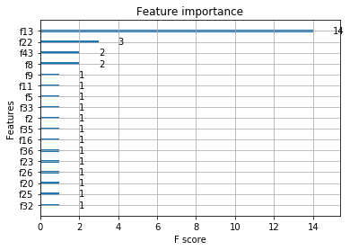

```python
from xgboost import plot_importance
from matplotlib import pyplot
y = plot_importance(bst_xgboost)
```

```python
cols = list(train.columns)
del cols[cols.index('item_cnt_day')] # eliminate target feature col name
[cols[x] for x in [13, 22, 43, 8, 9, 11, 5, 33, 2]]
```

```
['item_cnt_day_lag_1',
 'item_category_id_avg_item_cnt_day_lag_2',
 'item_cnt_day_lag_6',
 'shop_id_sum_item_cnt_day_lag_1',
 'shop_id_avg_item_cnt_day_lag_1',
 'item_category_id_sum_item_cnt_day_lag_1',
 'item_id_sum_item_cnt_day_lag_1',
 'item_cnt_day_lag_3',
 'date_block_num']
```

A continuacion se muestran las importancias en función de la ganancia promedio de los splits que utilizan cada característica

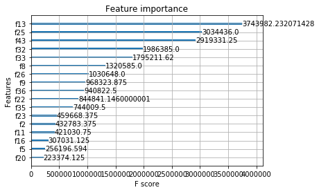

```python
w = plot_importance(bst_xgboost,importance_type='gain', max_num_features=None)
```

```python
cols = list(train.columns)
del cols[cols.index('item_cnt_day')] # eliminate target feature col name
[cols[x] for x in [13, 25, 43, 32, 33, 8, 26, 9, 36, 22]]
```

```
['item_cnt_day_lag_1',
 'item_id_sum_item_cnt_day_lag_3',
 'item_cnt_day_lag_6',
 'item_category_id_avg_item_cnt_day_lag_3',
 'item_cnt_day_lag_3',
 'shop_id_sum_item_cnt_day_lag_1',
 'item_id_avg_item_cnt_day_lag_3',
 'shop_id_avg_item_cnt_day_lag_1',
 'item_id_avg_item_cnt_day_lag_6',
 'item_category_id_avg_item_cnt_day_lag_2']
```

```python
test = pd.read_csv("Data_Modelos/Prueba_Modelos.csv")
```

```python
X_test = test.iloc[:, test.columns != 'item_cnt_day'].values
```

```python
pred_xgboost = bst_xgboost.predict(X_test)
```

```python
pd.Series(pred_xgboost).describe()
```

```
count    214200.000000
mean          0.339867
std           1.696063
min           0.252737
25%           0.252737
50%           0.252737
75%           0.252737
max         354.639465
dtype: float64
```

```python
pred_xgboost = pred_xgboost.clip(0, 20)
```

```python
pd.Series(pred_xgboost).describe()
```

```
count    214200.000000
mean          0.326821
std           0.587214
min           0.252737
25%           0.252737
50%           0.252737
75%           0.252737
max          20.000000
dtype: float64
```

```python
pred_xgboost.sum()
```

```
69955.22
```

```python
sub_df_xgboost = pd.DataFrame({'ID':test.index,'item_cnt_month': pred_xgboost })
```

```python
sub_df_xgboost.head()
```

|  | ID | item_cnt_month |
| --- | --- | --- |
| 0 | 0 | 0.252737 |
| 1 | 1 | 0.252737 |
| 2 | 2 | 0.499186 |
| 3 | 3 | 0.252737 |
| 4 | 4 | 0.252737 |

```python
sub_df_xgboost.to_csv('Modelo_Final/submission_xgboost.csv',index = False, header=True)
```

```python
from sklearn.externals import joblib
joblib.dump(bst_xgboost, 'Modelo_Final/modelo_xgboost.pkl')
```

```
['Modelo_Final/modelo_xgboost.pkl']
```

```python
import pickle
```

```python
with open("modelo_xgboost.pkl", "wb") as f:
    pickle.dump(bst_xgboost, f)
```